# Tutorial: Single Cell RNA-Seq Analysis of NK, CD4+ and CD8+ T cells isolated from LCMV infected WT and Ifng - CTCF binding site mutant mice, using SCassist - an AI-Based Workflow Assistant

## 3. Variable features

Explore the variable features using the LLMs abilities to glean insights in to a list of genes, to explore what drives the cell-to-cell variation. Here we ask SCassist_analyze_variable_features to explore the top 30 variable features, along with the experimental design statement and provide potential insights on the underlying system being studied.

```r
# Experimental design statement
experimental_design = "NK, CD4+ and CD8+ T cells isolated from lymphocytic choriomeningitis virus infected WT and Ifng - CTCF binding site mutant mice"

# List top 10 variable genes
top10 <- head(VariableFeatures(allsamplesgood), 10)
top10
```

```
##  [1] "Gzma"      "Ccl5"      "Hist1h2ap" "Hist1h1b"  "Ccl4"      "Gzmb"
##  [7] "Hist1h2ae" "Tyrobp"    "Klra4"     "Xcl1"
```

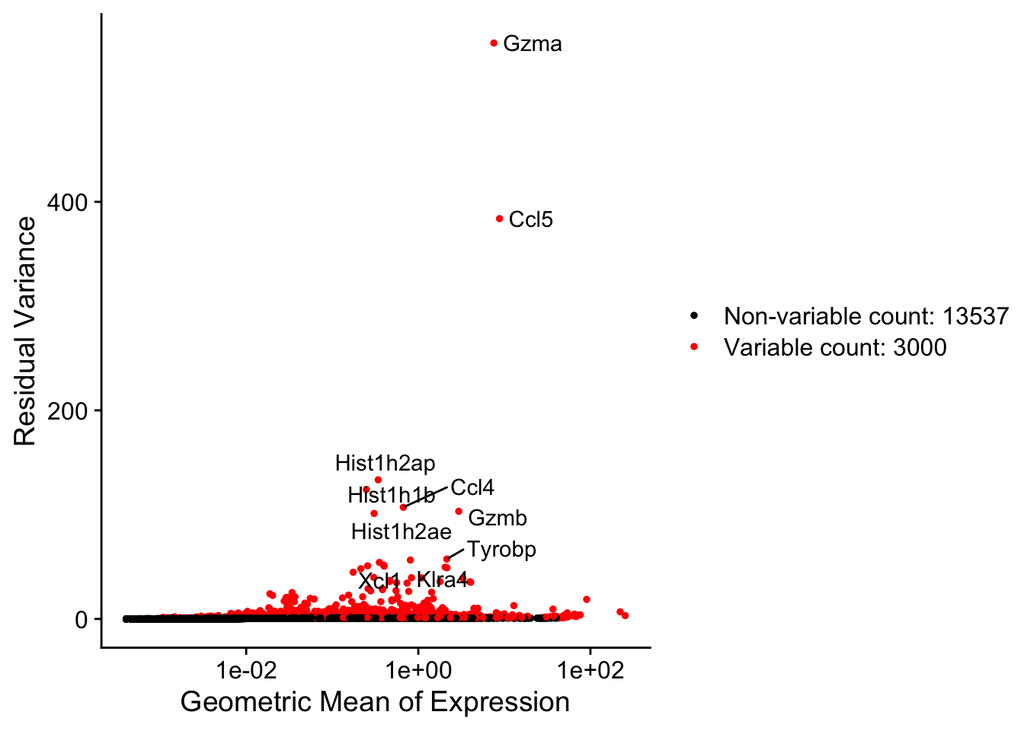

```r
# Plot variable features, label the top 10, save the plot
vfp1 <- VariableFeaturePlot(allsamplesgood)
vfp1 <- LabelPoints(plot = vfp1, points = top10, repel = TRUE)
vfp1
```

```r
ggsave(paste(outputpath,"LCMV-variablefeatureplot.pdf",sep=""), plot = vfp1, width = 20, height = 15, units = "cm")

# Analyze variable features (top 30 default genes)
variable_feature_analysis <- SCassist_analyze_variable_features("allsamplesgood", experimental_design = experimental_design, api_key_file = api_key_file, llm_server = "google")
```

```
## ## Enriched Gene Ontologies and Pathways:
##
## The provided list of genes suggests enrichment in several key pathways and functions related to **immune response, cell cycle, and inflammation**.
##
## **1. Immune Response:**
##
## * **NK cell activation and cytotoxicity:**  Genes like *Gzma, Gzmb, Nkg7, Klra1, Klra4, Klra7, Klra8, Klra9* are all involved in NK cell function. *Gzma* and *Gzmb* are granzyme proteins that induce apoptosis in target cells, while *Nkg7* is a receptor involved in NK cell activation. The *Klra* g…
## * **Chemokine signaling:**  Genes like *Ccl3, Ccl4, Ccl5, Cxcl10, Xcl1* are chemokines involved in attracting and activating immune cells, particularly T cells and NK cells.
## * **Antigen presentation:** *Tyrobp* encodes a protein involved in the signaling pathway of the Fc receptor, which plays a role in antigen presentation and immune cell activation.
## * **T cell activation and differentiation:** *Ikzf2* is a transcription factor involved in T cell development and differentiation.
##
## **2. Cell Cycle and Proliferation:**
##
## * **Cell cycle regulation:** *Mki67* is a marker of proliferating cells, while *Top2a* is involved in DNA replication and repair.
## * **Cell growth and differentiation:** *Stmn1* is a protein involved in microtubule dynamics and cell growth.
##
## **3. Inflammation and Tissue Repair:**
##
## * **Inflammation:** *S100a4, S100a6, Hmgb2* are involved in inflammation and immune response.
## * **Extracellular matrix remodeling:** *Spp1* encodes osteopontin, a protein involved in extracellular matrix remodeling and inflammation.
##
## **Relevance to Experimental Design:**
##
## The identified gene ontologies and pathways are highly relevant to the experimental design involving NK, CD4+, and CD8+ T cells isolated from lymphocytic choriomeningitis virus (LCMV) infected WT and Ifng - CTCF binding site mutant mice.
##
## * **LCMV infection:** LCMV is a virus that induces a robust immune response, involving both NK cells and T cells. The genes identified are likely involved in the immune response to LCMV infection.
## * **NK cell function:** The enrichment of genes involved in NK cell activation and cytotoxicity suggests that NK cells play a significant role in the immune response to LCMV infection.
## * **T cell function:** The presence of genes involved in T cell activation, differentiation, and chemokine signaling indicates that T cells are also actively involved in the immune response.
## * **Ifng - CTCF binding site mutant mice:** The mutation in the Ifng - CTCF binding site likely affects the expression of genes involved in the immune response, potentially altering the activation and function of NK and T cells.
##
## By analyzing the expression of these genes in WT and mutant mice, researchers can gain insights into the role of NK and T cells in the immune response to LCMV infection and how the mutation in the Ifng - CTCF binding site affects these processes.
```

## 4. PCA

Here we perform PCA and ask SCassist_recommend_pcs to analzye the PCs to provide recommendation for the number of PCs to use for downstream analysis.

```r
# Run PCA to generate 50 pcs
allsamplesgood <- RunPCA(object = allsamplesgood, npcs=50)

# Print genes in the top 5 pcs
print(allsamplesgood[["pca"]], dims = 1:5, nfeatures = 5)
```

```
## PC_ 1
## Positive:  Gzma, Ccl5, Gzmb, Tyrobp, Fcer1g
## Negative:  Ly6c1, Ltb, Ikzf2, Rps27, Cd3d
## PC_ 2
## Positive:  Hist1h2ap, Hist1h1b, Hist1h2ae, Top2a, Mki67
## Negative:  Ccl5, Gzma, Gzmb, Tyrobp, Ccl4
## PC_ 3
## Positive:  Ccl5, Gzma, Cd8b1, Rps27, Rps24
## Negative:  C1qa, Slc40a1, C1qc, Hmox1, Vcam1
## PC_ 4
## Positive:  Ly6c2, Cd8b1, Ly6c1, Dapl1, Plac8
## Negative:  Ikzf2, Tnfrsf4, Foxp3, Tnfrsf9, Izumo1r
## PC_ 5
## Positive:  Ccl4, Xcl1, Ccl3, Gzmb, Spp1
## Negative:  Ccl5, Gzma, Cma1, S100a6, Cenpf
```

### 4.1. Choosing appropriate number of PCs

Here we ask SCassist_recommend_pcs to analzye the PCs to provide recommendation for the number of PCs to use for downstream analysis. We also ask SCassist_analyze_pcs to analzye the SCassist recommended PCs and provide insights on the gene sets identified.

```r
# Identify appropriate PCs to use
pc_recommendation=SCassist_recommend_pcs("allsamplesgood", experimental_design = experimental_design, api_key_file = api_key_file, llm_server = "google")
```

```
## Based on the provided variance explained by each PC, the optimal number of PCs to use for downstream analysis is **10**.
##
## Here's the reasoning:
##
## * **Elbow point:** While there isn't a super clear "elbow" in the scree plot, there's a noticeable change in slope around PC10. The variance explained drops significantly after PC10, indicating that the subsequent PCs capture less substantial information.
## * **Variance explained:** The first 10 PCs capture approximately 70% of the total variance (34.35% + 15.63% + 6.67% + 3.91% + 2.88% + 2.5% + 2.35% + 2.11% + 2.01% + 1.9% = 70.31%). This is a good balance between capturing most of the variation and avoiding excessive complexity.
## * **Balance between complexity and interpretability:** Using 10 PCs provides a reasonable level of detail while maintaining interpretability. Including more PCs might capture subtle variations but could lead to overfitting and make the analysis harder to understand.
##
## Therefore, using 10 PCs strikes a balance between capturing most of the variance and maintaining a manageable level of complexity for downstream analysis.
```

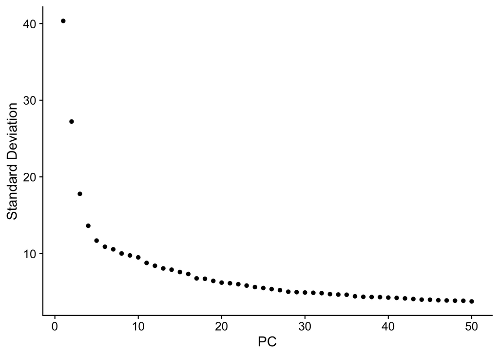

```r
# Identify number of PCs that explains majority of variations
ElbowPlot(allsamplesgood, ndims=50, reduction = "pca")
```

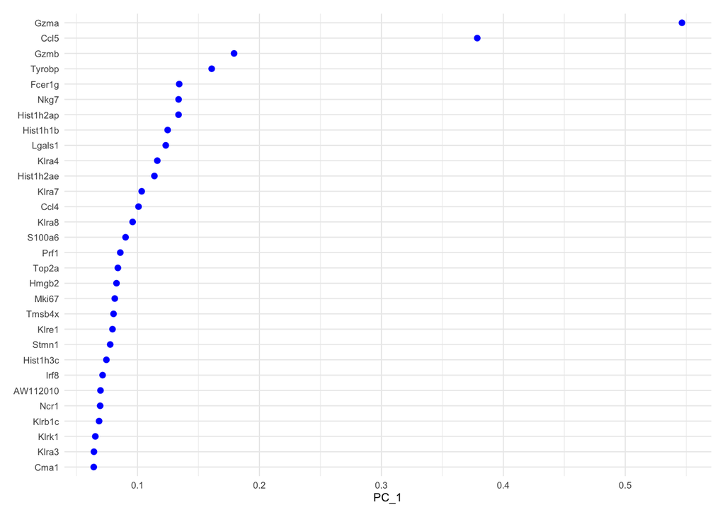

```r
# Visualize the genes in the first PC
VizDimLoadings(allsamplesgood, dims = 1, ncol = 1) + theme_minimal(base_size = 8)
```

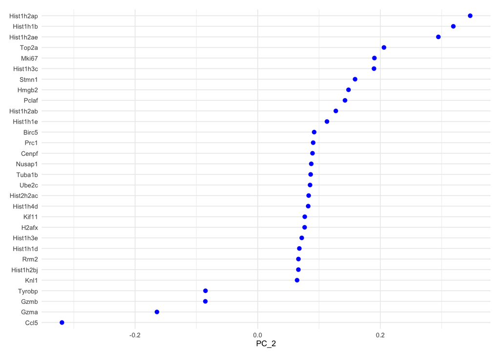

```r
# Visualize the genes in the second PC
VizDimLoadings(allsamplesgood, dims = 2, ncol = 1) + theme_minimal(base_size = 8)
```

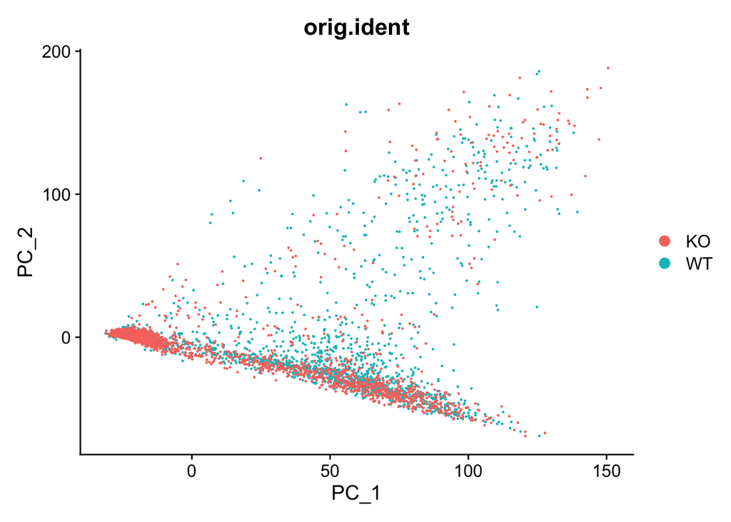

```r
# Set the identity column to  WT vs KO
Idents(allsamplesgood) <- "orig.ident"

# Visualize the cells after pca
DimPlot(object = allsamplesgood, reduction = "pca", group.by = "orig.ident")
```

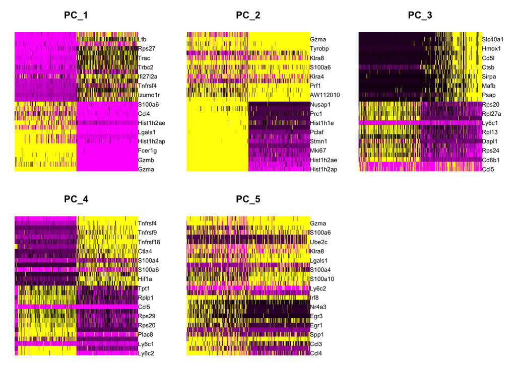

```r
# Plot heatmap with cells=500 plotting cells with extreme cells on both ends of spectrum
DimHeatmap(object = allsamplesgood, dims = 1:5, cells = 500, balanced = TRUE)
```

```r
# Here we are also analyzing the gene sets that make up the top 5 PCs, top_n_pc_contributing_genes = 50
pc_analyzed=SCassist_analyze_pcs("allsamplesgood", num_pcs = 5, experimental_design = experimental_design, api_key_file = api_key_file, llm_server = "google")
```

```
##
## **PC1 Summary:**
## The top contributing genes for PC1 are primarily associated with cytotoxic T cell function and inflammation. Genes like *Gzma*, *Gzmb*, *Prf1*, *Nkg7*, and *Klra* family members are all involved in granule exocytosis and killing of target cells.  *Ccl3*, *Ccl4*, and *Ccl5* are chemokines that att…
##
## Taken together, these genes suggest that PC1 might be capturing variations in the cytotoxic activity and inflammatory response of CD4+ and CD8+ T cells in the context of lymphocytic choriomeningitis virus infection. The differences in gene expression between WT and Ifng-CTCF binding site mutant m…
##
##
## **PC2 Summary:**
## The top contributing genes for PC2 are primarily involved in cell cycle regulation, proliferation, and immune response. Genes like *Mki67*, *Ccna2*, *Cdk1*, *Cenpf*, *Kif11*, and *Tuba1b* are known to be crucial for cell division and proliferation.  *Gzma*, *Gzmb*, *Klra8*, *Ccl5*, and *Ccl4* are…
##
## Therefore, PC2 likely captures variations in the cellular state related to T cell activation, proliferation, and cytotoxic activity. This could be driven by differences in the immune response to lymphocytic choriomeningitis virus infection between WT and Ifng - CTCF binding site mutant mice.
##
##
## **PC3 Summary:**
## The top contributing genes for PC3 are primarily involved in immune response, inflammation, and macrophage activation. Genes like C1qa, C1qc, C1qb, and Cfb are components of the complement system, which plays a crucial role in innate immunity and inflammation. Other genes like Hmox1, Vcam1, and C…
##
##
## **PC4 Summary:**
## The top contributing genes for PC4 include several key players in T cell activation, differentiation, and function. Notably, we see genes like **Ikzf2 (Helios)**, a transcription factor associated with regulatory T cell (Treg) development, **Foxp3**, the master regulator of Treg function, and **C…
##
## Taken together, these genes suggest that PC4 might be capturing variations in the balance between Treg and CTL populations, potentially reflecting differences in immune responses to lymphocytic choriomeningitis virus (LCMV) infection between WT and Ifng-CTCF binding site mutant mice. This could b…
##
##
## **PC5 Summary:**
## The top contributing genes for PC5 are primarily associated with immune response and inflammation. Genes like *Ccl4, Xcl1, Ccl3, Ccl5, Cxcl10, Ifng, Gzmb, Gzma, Tnfrsf9* are chemokines and cytokines involved in attracting and activating immune cells, particularly T cells and NK cells.  *Egr1, Egr…
##
##
## ## Overall Summary of Principal Components (PCs)
##
## The five principal components (PCs) identified in this study capture distinct aspects of the immune response to lymphocytic choriomeningitis virus (LCMV) infection, particularly in the context of differences between wild-type (WT) and Ifng-CTCF binding site mutant mice.
##
## **PC1:** Primarily reflects variations in **cytotoxic T cell function and inflammation**. This component highlights genes involved in granule exocytosis, target cell killing, chemokine production, and immune signaling. Differences in PC1 scores between WT and mutant mice could indicate variations…
##
## **PC2:** Captures variations in **T cell activation, proliferation, and cytotoxic activity**. This component includes genes crucial for cell division, proliferation, and immune response, suggesting differences in the cellular state of T cells between WT and mutant mice.
##
## **PC3:** Focuses on **immune response, inflammation, and macrophage activation**. This component highlights genes involved in the complement system, macrophage activation and recruitment, and antiviral responses. Differences in PC3 scores could reflect variations in the activation and recruitment…
##
## **PC4:** Reflects variations in the **balance between regulatory T cells (Tregs) and cytotoxic T cells (CTLs)**. This component includes genes associated with Treg development and function, as well as CTL activity. Differences in PC4 scores could indicate altered T cell differentiation pathways, …
##
## **PC5:** Captures variations in the **activation, differentiation, and effector functions of T cells and NK cells**. This component includes genes involved in chemokine and cytokine production, T cell activation and differentiation, and antiviral responses. The presence of genes involved in both …
##
## **Overall, these PCs provide a comprehensive view of the complex immune response to LCMV infection, highlighting the distinct roles of different immune cell populations and pathways in controlling viral infection. The differences observed between WT and Ifng-CTCF binding site mutant mice suggest …
```

## 5. FindNeighbors

Here we ask SCassist_recommend_k to identify optimum number for k, to use with FindNeighbors function, given the number of pcs we are going to use for the downstream analysis.

```r
# Run SCassist_recommend_k to identify data based K
recommended_k <- SCassist_recommend_k("allsamplesgood", num_pcs = 10, api_key_file = api_key_file, llm_server = "google", experimental_design = experimental_design)
```

```
## ## Recommended K: 15-30
##
## ## Reasoning:
##
## The `k.param` value in `FindNeighbors()` determines the number of nearest neighbors considered for each cell when constructing the k-nearest neighbor graph. A higher `k.param` value leads to a more connected graph, potentially capturing broader relationships between cells. However, too high a val…
##
## Given your dataset of approximately 8555 cells and the use of 10 principal components, a range of `k.param` values between 15 and 30 is recommended. This range allows for a balance between capturing local relationships within clusters while still considering broader connections between different …
```

```r
# Run findneighbors
allsamplesgood <- FindNeighbors(allsamplesgood, dims = 1:10, k.param = 15, return.neighbor = TRUE)
```

## 6. Clustering

Here we ask SCassist_recommend_res to analyze the number of cells, number of genes, mean expression variability and median neighbor distance, and recommend appropriate cluster resolutions.

```r
# Run SCassist_recommend_res
recommended_res <- SCassist_recommend_res("allsamplesgood",  api_key_file = api_key_file, llm_server = "google")
```

```
## Based on the data characteristics, I recommend the following resolution range:
##
## **Recommended Resolution:** seq(0.4, 1.2, 0.1)
##
## **Reasoning:**
##
## The mean expression variability of 8.66843315573589 suggests a moderate level of heterogeneity in your dataset. This indicates that there might be subtle differences in gene expression between cell populations. The median neighbor distance of 4.83575773239136 in the k-nearest neighbor graph furth…
##
## Therefore, a resolution range of seq(0.4, 1.2, 0.1) is recommended. This range allows for the identification of both distinct and subtle cell populations. Lower resolutions (0.4-0.7) will capture broader, more general cell types, while higher resolutions (0.8-1.2) will enable the identification o…
```

```r
allsamplesgood <- FindNeighbors(allsamplesgood, dims = 1:10, k.param = 15)

# Perform clustering using the above identified resolution.
allsamplesgood <- FindClusters(allsamplesgood, resolution = seq(0.4,1.2,0.1))
```

[output not shown]

[output cut: 26 more lines]

```
## Number of edges: 241353
##
## Running Louvain algorithm...
## Maximum modularity in 10 random starts: 0.8370
## Number of communities: 21
## Elapsed time: 0 seconds
## Modularity Optimizer version 1.3.0 by Ludo Waltman and Nees Jan van Eck
##
## Number of nodes: 8555
## Number of edges: 241353
##
## Running Louvain algorithm...
## Maximum modularity in 10 random starts: 0.8317
## Number of communities: 23
## Elapsed time: 0 seconds
```

```r
head(allsamplesgood)
```

```
##                     orig.ident nCount_RNA nFeature_RNA percent.mito
## AAACCCAAGAGTTGTA-WT         WT      17880         4120     3.333333
## AAACCCAAGATTTGCC-WT         WT       7916         2395     2.627590
## AAACCCACAAGTATCC-WT         WT       9059         2865     1.953858
## AAACCCAGTCCAGGTC-WT         WT      10948         2939     2.831567
## AAACCCATCCTGGGAC-WT         WT      16768         3484     0.942271
## AAACGAACAGAGAGGG-WT         WT      10467         3159     3.668673
## AAACGAACAGCGACAA-WT         WT      12996         2853     1.569714
## AAACGAACAGTGTGGA-WT         WT      26674         4654     1.570818
## AAACGAATCTAGCCTC-WT         WT      11434         3100     1.687948
## AAACGCTAGCGTTCCG-WT         WT      28638         4519     3.579161
##                     percent.ribo  percent.hb nCount_SCT nFeature_SCT
## AAACCCAAGAGTTGTA-WT     22.80761 0.011185682      10914         3831
## AAACCCAAGATTTGCC-WT     16.28348 0.000000000       9352         2394
## AAACCCACAAGTATCC-WT     16.81201 0.000000000       9513         2863
## AAACCCAGTCCAGGTC-WT     25.30142 0.009134088      10388         2936
## AAACCCATCCTGGGAC-WT     35.07276 0.005963740      10691         3307
## AAACGAACAGAGAGGG-WT     22.92921 0.009553836      10239         3158
## AAACGAACAGCGACAA-WT     42.22068 0.000000000      10582         2853
## AAACGAACAGTGTGGA-WT     26.22029 0.000000000      10379         2877
## AAACGAATCTAGCCTC-WT     28.44149 0.000000000      10519         3100
## AAACGCTAGCGTTCCG-WT     43.16642 0.000000000       9760         2387
##                     SCT_snn_res.0.4 SCT_snn_res.0.5 SCT_snn_res.0.6
## AAACCCAAGAGTTGTA-WT               5               4               2
## AAACCCAAGATTTGCC-WT               4               6               5
## AAACCCACAAGTATCC-WT               5               4               2
## AAACCCAGTCCAGGTC-WT               3               5               1
## AAACCCATCCTGGGAC-WT               0               2               7
## AAACGAACAGAGAGGG-WT               7               7               8
## AAACGAACAGCGACAA-WT               2               1               0
## AAACGAACAGTGTGGA-WT               8               8               9
## AAACGAATCTAGCCTC-WT               3               5               1
## AAACGCTAGCGTTCCG-WT               0               2               6
##                     SCT_snn_res.0.7 SCT_snn_res.0.8 SCT_snn_res.0.9
## AAACCCAAGAGTTGTA-WT               5               3               8
## AAACCCAAGATTTGCC-WT               4               5               4
## AAACCCACAAGTATCC-WT              13              13              14
## AAACCCAGTCCAGGTC-WT               1               1               3
## AAACCCATCCTGGGAC-WT               6               7               6
## AAACGAACAGAGAGGG-WT               7               8               7
```

[output cut: 11 more lines]

```
## AAACGAACAGCGACAA-WT             1               1              19
## AAACGAACAGTGTGGA-WT             9               8              11
## AAACGAATCTAGCCTC-WT             3               3               4
## AAACGCTAGCGTTCCG-WT             7               4               5
##                     seurat_clusters
## AAACCCAAGAGTTGTA-WT               9
## AAACCCAAGATTTGCC-WT               6
## AAACCCACAAGTATCC-WT              18
## AAACCCAGTCCAGGTC-WT              13
## AAACCCATCCTGGGAC-WT               3
## AAACGAACAGAGAGGG-WT               8
## AAACGAACAGCGACAA-WT              19
## AAACGAACAGTGTGGA-WT              11
## AAACGAATCTAGCCTC-WT               4
## AAACGCTAGCGTTCCG-WT               5
```

```r
# Count number of clusters at each resolution
sapply(grep("res",colnames(allsamplesgood@meta.data),value = TRUE),
       function(x) length(unique(allsamplesgood@meta.data[,x])))
```

```
## SCT_snn_res.0.4 SCT_snn_res.0.5 SCT_snn_res.0.6 SCT_snn_res.0.7 SCT_snn_res.0.8
##              10              12              13              14              14
## SCT_snn_res.0.9   SCT_snn_res.1 SCT_snn_res.1.1 SCT_snn_res.1.2
##              17              21              21              23
```

```r
# change default identity
Idents(allsamplesgood) <- "SCT_snn_res.1.1"

# list cell number in each cluster for HC vs UV
table(Idents(allsamplesgood),allsamplesgood$orig.ident)
```

```
##
##       KO  WT
##   0  505 400
##   1  438 417
##   2  531 280
##   3  128 618
##   4  478 209
##   5  277 399
##   6  232 375
##   7  303 154
##   8  135 317
##   9  197 162
##   10 111 231
##   11 149 183
##   12  95 187
##   13  17 209
##   14  69  95
##   15 110  51
##   16  58 101
##   17  70  56
##   18  36  62
##   19  30  53
##   20  10  17
```

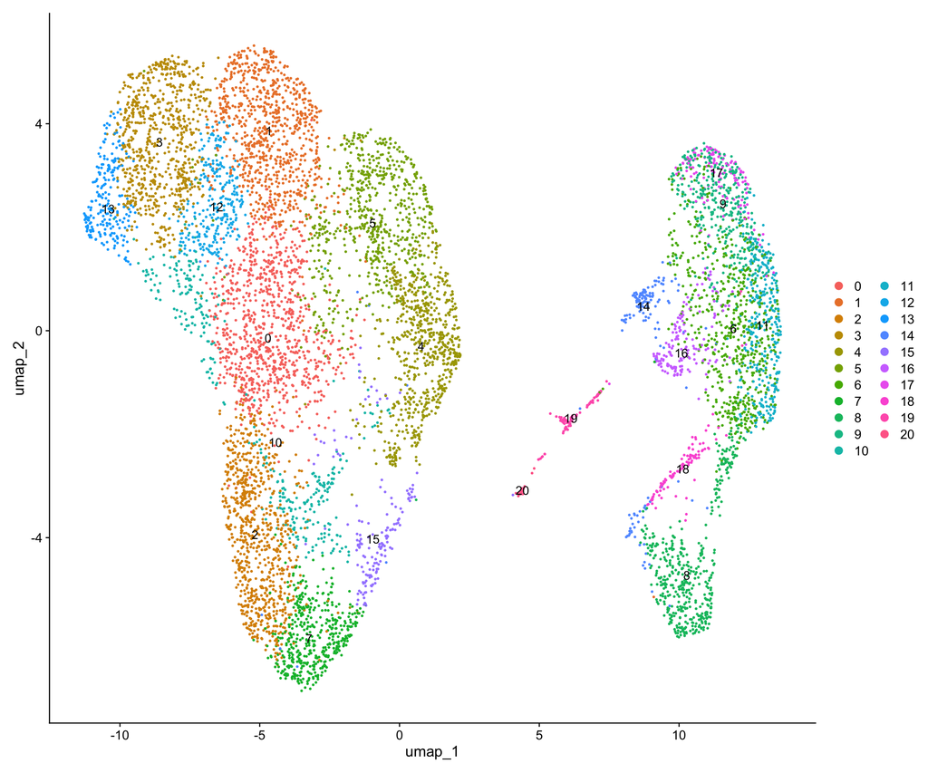

```r
set.seed(20)

# Run UMAP with identified dimensions
allsamplesgood <- RunUMAP(allsamplesgood, dims = 1:10)

# Plot umap
DimPlot(object = allsamplesgood, pt.size=0.5, reduction = "umap", label = T)
```

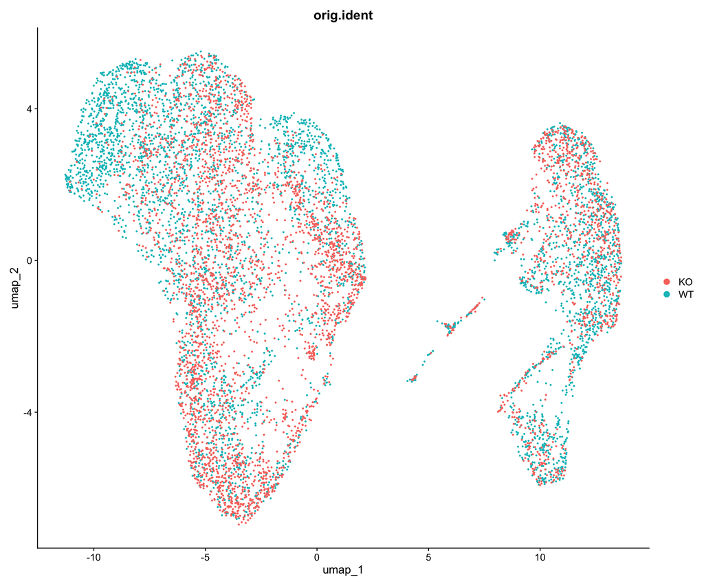

```r
# Color by WT vs KO
DimPlot(object = allsamplesgood, pt.size=0.5, reduction = "umap", group.by = "orig.ident")
```

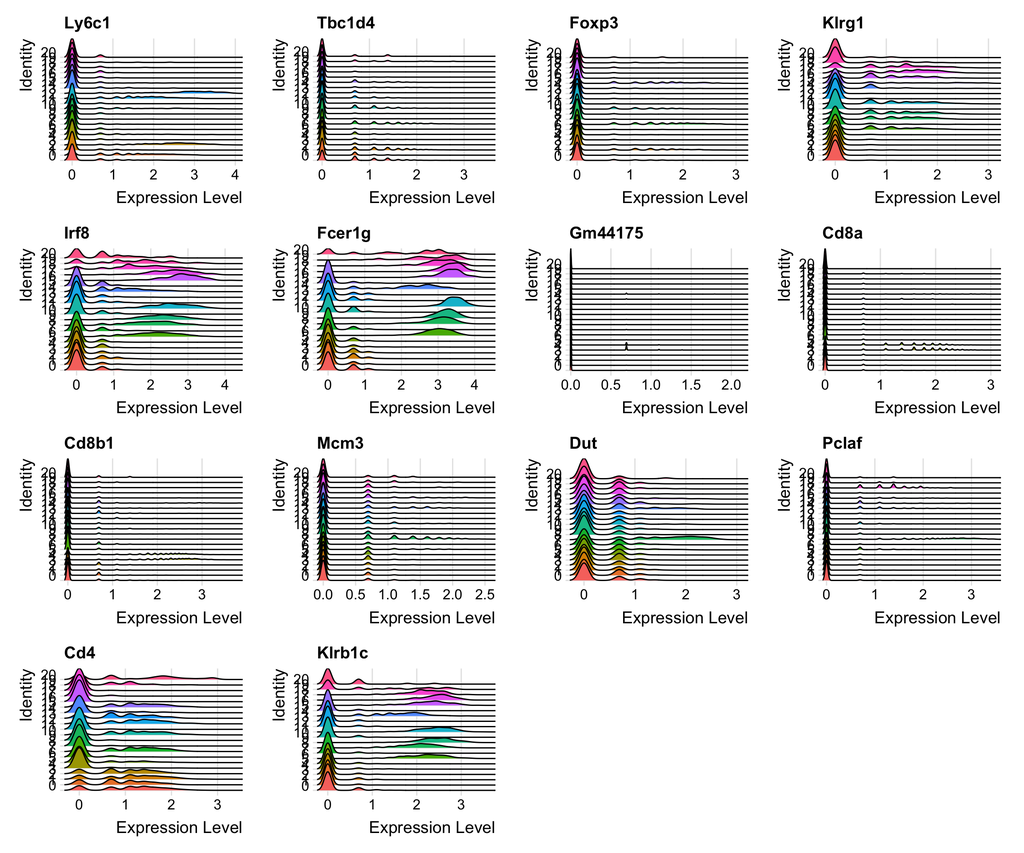

```r
# Plot umap
dimplot1<-DimPlot(object = allsamplesgood, pt.size=0.5, reduction = "umap", label = T)

# Color by WT vs KO
dimplot2<-DimPlot(object = allsamplesgood, pt.size=0.5, reduction = "umap", group.by = "orig.ident")

# Save umaps
ggsave(paste(outputpath,"LCMV-umap-clusters.pdf",sep=""), plot = dimplot1, width = 20, height = 15, units = "cm")
ggsave(paste(outputpath,"LCMV-umap-clusters-type.pdf",sep=""), plot = dimplot2, width = 20, height = 15, units = "cm")

# Custom list of genes to visualize
mygenes = c("Ly6c1", "Tbc1d4","Foxp3","Klrg1", "Irf8","Fcer1g","Gm44175","Cd8a","Cd8b1","Mcm3","Dut","Pclaf","Cd4","Klrb1c")
RidgePlot(allsamplesgood, features = mygenes)
```

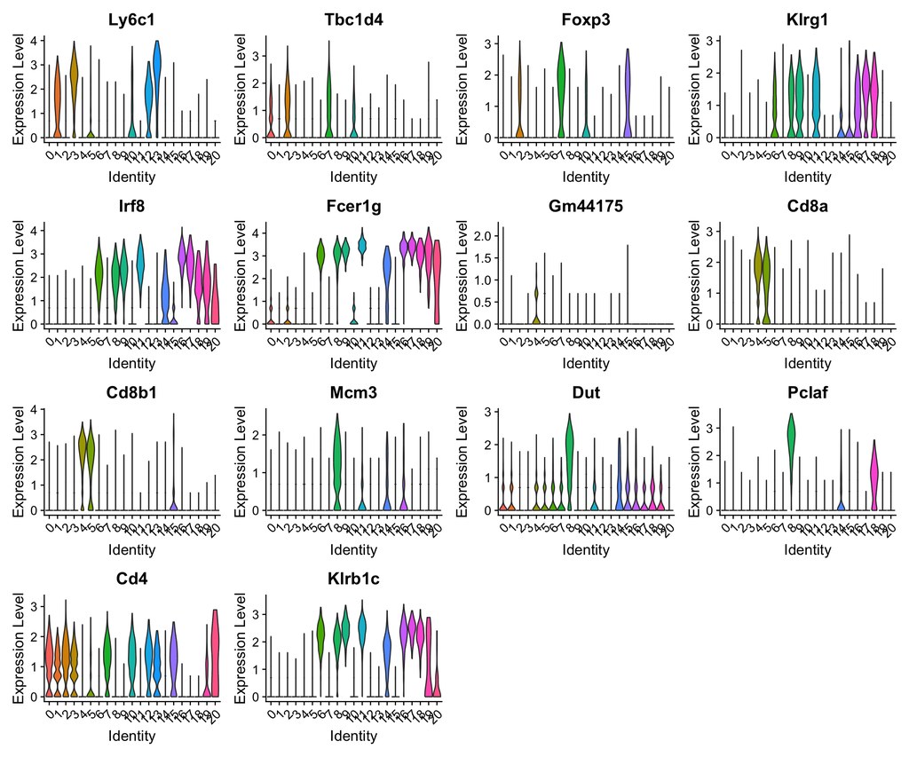

```r
VlnPlot(allsamplesgood, features = mygenes, pt.size=0)
```

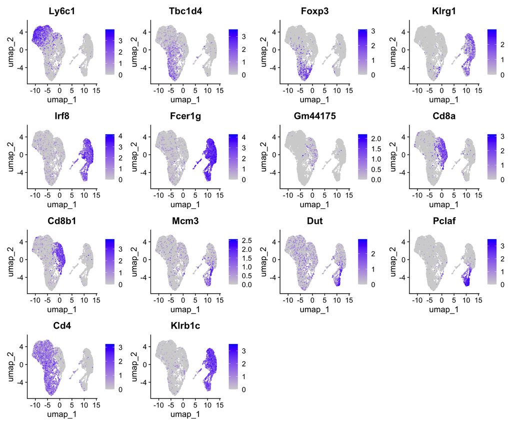

```r
FeaturePlot(allsamplesgood, features = mygenes)
```

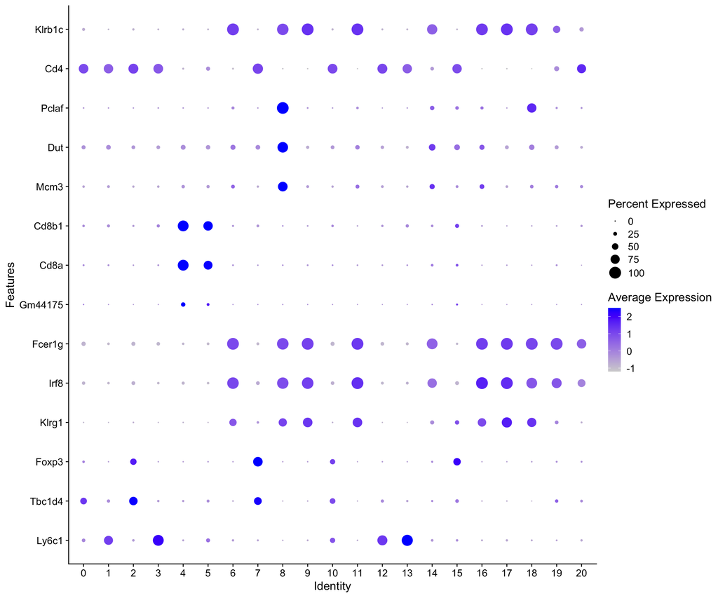

```r
DotPlot(allsamplesgood, features = mygenes) + coord_flip()
```

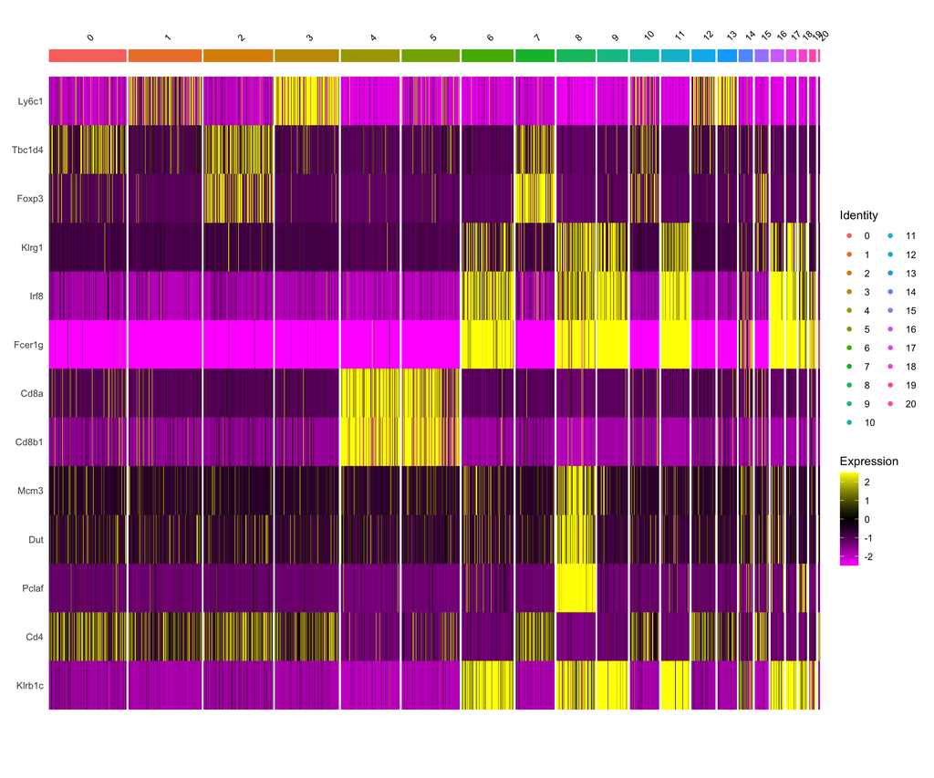

```r
DoHeatmap(subset(allsamplesgood), features = mygenes, size = 3)
```

## 7. Marker Identification

Here we run findallmarkers to identify potential markers that are unique for each of the clusters.

```r
########################### Find all markers (about 80 minutes)
#markersall=FindAllMarkers(allsamplesgood)
head(markersall)
```

```
##               p_val avg_log2FC pct.1 pct.2    p_val_adj cluster   gene
## Tbc1d4 1.158042e-86  1.0800634 0.517 0.214 1.915055e-82       0 Tbc1d4
## Cd4    1.364313e-84  0.9398292 0.794 0.464 2.256164e-80       0    Cd4
## Ctsw   3.829336e-84 -2.4903435 0.220 0.522 6.332572e-80       0   Ctsw
## Slamf6 1.890603e-78  1.0467176 0.760 0.484 3.126491e-74       0 Slamf6
## Sell   8.866188e-77 -1.1435992 0.636 0.816 1.466202e-72       0   Sell
## Bcl11b 3.750989e-74  0.7344389 0.920 0.644 6.203011e-70       0 Bcl11b
```

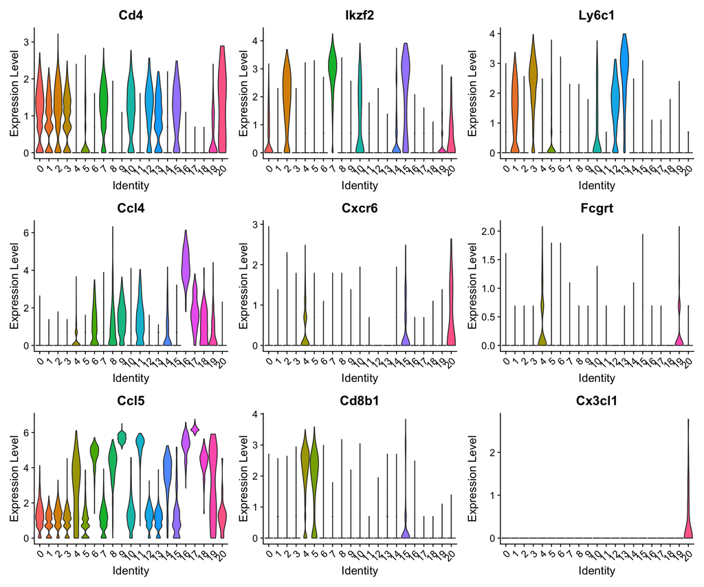

```r
# Save all markers as tab delimited file
write.table(markersall, file=paste(outputpath,"LCMV-markersall.txt",sep=""),quote=F, row.names = FALSE, sep = ",")

# Plot selected markers
VlnPlot(allsamplesgood,features=c("Cd4","Ikzf2", "Ly6c1","Ccl4","Cxcr6","Fcgrt","Ccl5","Cd8b1","Cx3cl1"), pt.size = 0)
```

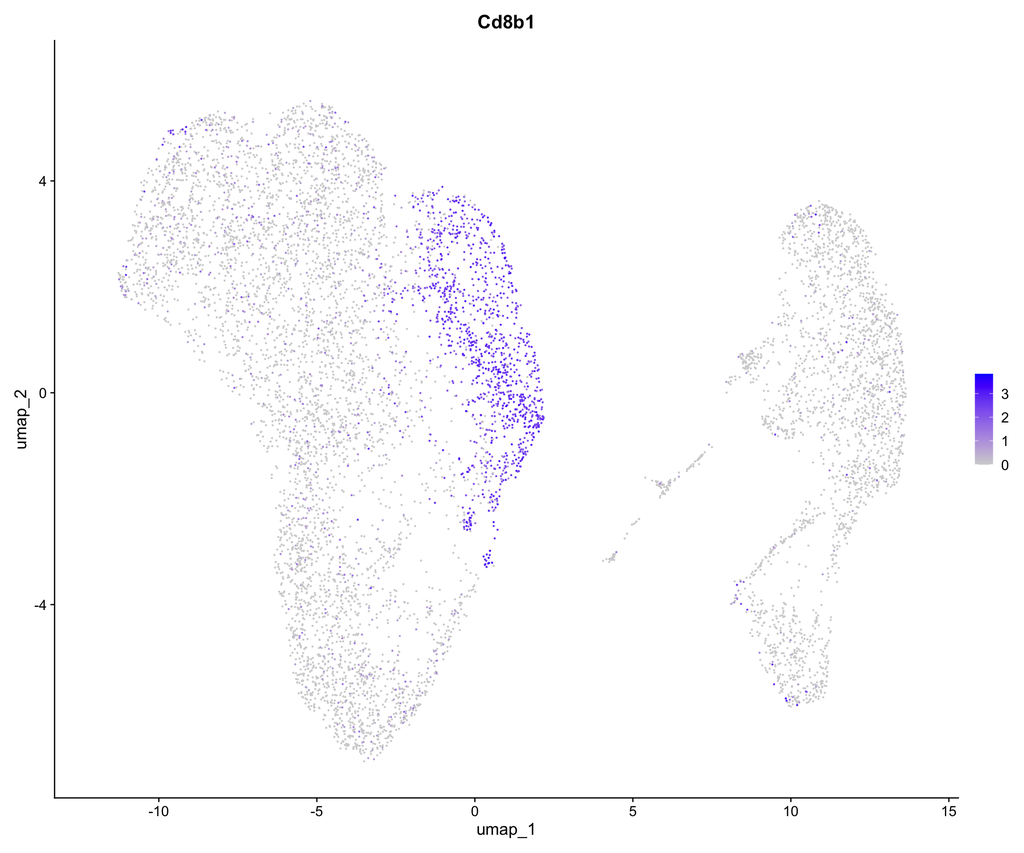

```r
FeaturePlot(allsamplesgood, features="Cd8b1")
```

```r
# Extract the top marker for each cluster
head(markersall)
```

```
##               p_val avg_log2FC pct.1 pct.2    p_val_adj cluster   gene
## Tbc1d4 1.158042e-86  1.0800634 0.517 0.214 1.915055e-82       0 Tbc1d4
## Cd4    1.364313e-84  0.9398292 0.794 0.464 2.256164e-80       0    Cd4
## Ctsw   3.829336e-84 -2.4903435 0.220 0.522 6.332572e-80       0   Ctsw
## Slamf6 1.890603e-78  1.0467176 0.760 0.484 3.126491e-74       0 Slamf6
## Sell   8.866188e-77 -1.1435992 0.636 0.816 1.466202e-72       0   Sell
## Bcl11b 3.750989e-74  0.7344389 0.920 0.644 6.203011e-70       0 Bcl11b
```

```r
markersall %>%
  group_by(cluster) %>%
  slice(1) %>%
  pull(gene) -> best.gene.per.cluster

best.gene.per.cluster
```

```
##  [1] "Tbc1d4"        "Rps29"         "Ikzf2"         "Ly6c1"
##  [5] "Fcgrt"         "Cd8a"          "Klrb1c"        "Itgb8"
##  [9] "Hist1h3b"      "Itgam"         "Slfn5"         "Lat2"
## [13] "Lef1"          "Ly6c1"         "Batf3"         "1500009L16Rik"
## [17] "Ccl4"          "Cma1"          "Hmmr"          "Lpl"
## [21] "Cx3cl1"
```

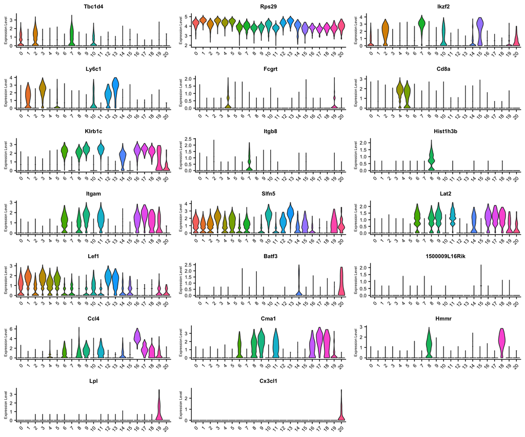

```r
# Store plot as ggplot list
vlnplot1<-VlnPlot(allsamplesgood,features=best.gene.per.cluster, pt.size = 0, combine = FALSE)

# Set properties for each plot in the list
p1 <- list()
for (i in seq_along(vlnplot1)){
  #Change x and y tick label font size.
  p1[[i]] = vlnplot1[[i]] +
    theme(legend.position = "none",
          axis.text.x = element_text(size = 8),
          axis.text.y = element_text(size = 8),
          axis.title.y = element_text(size = 6),
          axis.title.x = element_blank(),
          title = element_text(size=8))
}

# Plot all the plots in the list
plot_grid(plotlist = p1, ncol = 3)
```

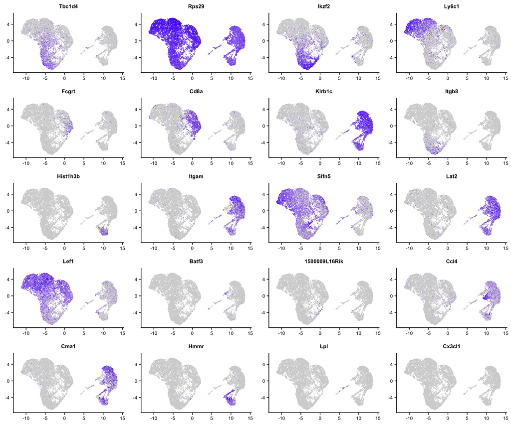

```r
# Save plot to file
vlnplot1=plot_grid(plotlist = p1, ncol = 3)
ggsave(paste(outputpath,"LCMV-vlnplot-best-per-cluster.pdf",sep=""), plot = vlnplot1, width = 20, height = 25, units = "cm")

# Plot features in umap
fplot1<-FeaturePlot(allsamplesgood,features=best.gene.per.cluster, pt.size = 0, combine = FALSE)
p2 <- list()
for (i in seq_along(fplot1)){
  #Change x and y label font size.
  p2[[i]] = fplot1[[i]] +
    theme(legend.position = "none",
          axis.text.x = element_text(size = 8),
          axis.text.y = element_text(size = 8),
          axis.title.y = element_blank(),
          axis.title.x = element_blank(),
          title = element_text(size=8))
}

plot_grid(plotlist = p2, ncol = 4)
```

```r
fplot1=plot_grid(plotlist = p2, ncol = 4)
ggsave(paste(outputpath,"LCMV-fplot-best-per-cluster.pdf",sep=""), plot = fplot1, width = 20, height = 25, units = "cm")
```

### 7.1. Computational Annotation

Here we use SCassist_analyze_and_annotate to analyze Top Markers, Predict Cell Types, and Optionally Annotate the Seurat Object.

```r
Idents(allsamplesgood) <- "SCT_snn_res.1.1"

head(allsamplesgood)
```

```
##                     orig.ident nCount_RNA nFeature_RNA percent.mito
## AAACCCAAGAGTTGTA-WT         WT      17880         4120     3.333333
## AAACCCAAGATTTGCC-WT         WT       7916         2395     2.627590
## AAACCCACAAGTATCC-WT         WT       9059         2865     1.953858
## AAACCCAGTCCAGGTC-WT         WT      10948         2939     2.831567
## AAACCCATCCTGGGAC-WT         WT      16768         3484     0.942271
## AAACGAACAGAGAGGG-WT         WT      10467         3159     3.668673
## AAACGAACAGCGACAA-WT         WT      12996         2853     1.569714
## AAACGAACAGTGTGGA-WT         WT      26674         4654     1.570818
## AAACGAATCTAGCCTC-WT         WT      11434         3100     1.687948
## AAACGCTAGCGTTCCG-WT         WT      28638         4519     3.579161
##                     percent.ribo  percent.hb nCount_SCT nFeature_SCT
## AAACCCAAGAGTTGTA-WT     22.80761 0.011185682      10914         3831
## AAACCCAAGATTTGCC-WT     16.28348 0.000000000       9352         2394
## AAACCCACAAGTATCC-WT     16.81201 0.000000000       9513         2863
## AAACCCAGTCCAGGTC-WT     25.30142 0.009134088      10388         2936
## AAACCCATCCTGGGAC-WT     35.07276 0.005963740      10691         3307
## AAACGAACAGAGAGGG-WT     22.92921 0.009553836      10239         3158
## AAACGAACAGCGACAA-WT     42.22068 0.000000000      10582         2853
## AAACGAACAGTGTGGA-WT     26.22029 0.000000000      10379         2877
## AAACGAATCTAGCCTC-WT     28.44149 0.000000000      10519         3100
## AAACGCTAGCGTTCCG-WT     43.16642 0.000000000       9760         2387
##                     SCT_snn_res.0.4 SCT_snn_res.0.5 SCT_snn_res.0.6
## AAACCCAAGAGTTGTA-WT               5               4               2
## AAACCCAAGATTTGCC-WT               4               6               5
## AAACCCACAAGTATCC-WT               5               4               2
## AAACCCAGTCCAGGTC-WT               3               5               1
## AAACCCATCCTGGGAC-WT               0               2               7
## AAACGAACAGAGAGGG-WT               7               7               8
## AAACGAACAGCGACAA-WT               2               1               0
## AAACGAACAGTGTGGA-WT               8               8               9
## AAACGAATCTAGCCTC-WT               3               5               1
## AAACGCTAGCGTTCCG-WT               0               2               6
##                     SCT_snn_res.0.7 SCT_snn_res.0.8 SCT_snn_res.0.9
## AAACCCAAGAGTTGTA-WT               5               3               8
## AAACCCAAGATTTGCC-WT               4               5               4
## AAACCCACAAGTATCC-WT              13              13              14
## AAACCCAGTCCAGGTC-WT               1               1               3
## AAACCCATCCTGGGAC-WT               6               7               6
## AAACGAACAGAGAGGG-WT               7               8               7
```

[output cut: 11 more lines]

```
## AAACGAACAGCGACAA-WT             1               1              19
## AAACGAACAGTGTGGA-WT             9               8              11
## AAACGAATCTAGCCTC-WT             3               3               4
## AAACGCTAGCGTTCCG-WT             7               4               5
##                     seurat_clusters
## AAACCCAAGAGTTGTA-WT               9
## AAACCCAAGATTTGCC-WT               6
## AAACCCACAAGTATCC-WT              18
## AAACCCAGTCCAGGTC-WT              13
## AAACCCATCCTGGGAC-WT               3
## AAACGAACAGAGAGGG-WT               8
## AAACGAACAGCGACAA-WT              19
## AAACGAACAGTGTGGA-WT              11
## AAACGAATCTAGCCTC-WT               4
## AAACGCTAGCGTTCCG-WT               5
```

```r
# Run computational annotation. If seurat_object_name is provided, annotation will be added to that object and returned as sca_annotated, otherwise, sca_annotated will have the annotation details. Annotation detail is also saved in the current working directory as G_sca_annotation_results.tsv.
sca_annotated <- SCassist_analyze_and_annotate(markersall, top_genes = 30, seurat_object_name = "allsamplesgood", api_key_file = api_key_file, llm_server = "google")
```

```
## [1] "The output of Analyze and Annotate is saved as a tab delimited text if your current working directory. If you provided the name of the seurat object, the annotation is also added to that object in the SCassist_annotation column"
## [1] "SCassistant is analyzing markers to predict cell types for cluster : 0"
## [1] "SCassistant is analyzing markers to predict cell types for cluster : 1"
## [1] "SCassistant is analyzing markers to predict cell types for cluster : 2"
## [1] "SCassistant is analyzing markers to predict cell types for cluster : 3"
## [1] "SCassistant is analyzing markers to predict cell types for cluster : 4"
## [1] "SCassistant is analyzing markers to predict cell types for cluster : 5"
## [1] "SCassistant is analyzing markers to predict cell types for cluster : 6"
## [1] "SCassistant is analyzing markers to predict cell types for cluster : 7"
## [1] "SCassistant is analyzing markers to predict cell types for cluster : 8"
## [1] "SCassistant is analyzing markers to predict cell types for cluster : 9"
## [1] "SCassistant is analyzing markers to predict cell types for cluster : 10"
## [1] "SCassistant is analyzing markers to predict cell types for cluster : 11"
## [1] "SCassistant is analyzing markers to predict cell types for cluster : 12"
## [1] "SCassistant is analyzing markers to predict cell types for cluster : 13"
```

[output cut: 51 more lines]

```r
# Print out Annotation details
#sca_annotation_results <- read.delim("G_sca_annotation_results.tsv", sep = "\t")
#print(sca_annotation_results)

# Assign sca_annotated seurat object back to allsamplesgood object
allsamplesgood = sca_annotated

Idents(allsamplesgood) <- "scassist_annotation_SCT_snn_res.1.1"

# Proportions and counts
prop.table(table(Idents(allsamplesgood), allsamplesgood$orig.ident))
```

```
##
##                                                                 KO          WT
##   NK cells                                             0.042080655 0.062185856
##   Natural Killer (NK) cells                            0.040444185 0.040327294
##   Neural progenitor cells                              0.004208065 0.007247224
##   Interferon-stimulated cells                          0.014962011 0.051431911
##   Cytotoxic T lymphocytes                              0.032378726 0.046639392
##   Regulatory T cells                                   0.097486850 0.050730567
##   T cell                                               0.177206312 0.141788428
##   Proliferating cells                                  0.015780245 0.037054354
##   Immune cells (likely macrophages or dendritic cells) 0.014962011 0.072238457
##   NK cell                                              0.008065459 0.011104617
##   Macrophage                                           0.003506721 0.006195207
##   B cell                                               0.001168907 0.001987142
##   T helper 2 (Th2) cells                               0.012857978 0.005961426
```

```r
table(Idents(allsamplesgood), allsamplesgood$orig.ident)
```

```
##
##                                                          KO   WT
##   NK cells                                              360  532
##   Natural Killer (NK) cells                             346  345
##   Neural progenitor cells                                36   62
##   Interferon-stimulated cells                           128  440
##   Cytotoxic T lymphocytes                               277  399
##   Regulatory T cells                                    834  434
##   T cell                                               1516 1213
##   Proliferating cells                                   135  317
##   Immune cells (likely macrophages or dendritic cells)  128  618
##   NK cell                                                69   95
##   Macrophage                                             30   53
##   B cell                                                 10   17
##   T helper 2 (Th2) cells                                110   51
```

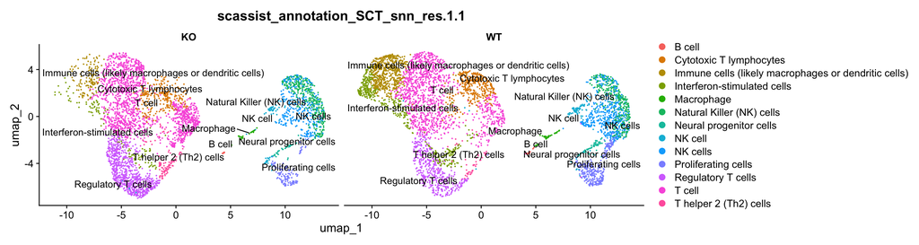

```r
DimPlot(allsamplesgood, reduction = "umap", label = TRUE, repel = TRUE, group.by = 'scassist_annotation_SCT_snn_res.1.1', split.by = "orig.ident")
```

```r
# create and save umap with labels
an0=DimPlot(allsamplesgood, reduction = "umap", label = TRUE, repel = TRUE, group.by = 'scassist_annotation_SCT_snn_res.1.1', split.by = "orig.ident")

#an0a=an0+theme(legend.position="none")
#an0
ggsave(paste(outputpath,"LCMV-umap-with-scassist.pdf",sep=""),plot=an0, width = 35, height = 13, units = "cm")
```

## 8. Proportion test

```r
Idents(allsamplesgood) <- "SCT_snn_res.1.2"

# Proportion test
# assign sample group
allsamplesgood$sample=ifelse(grepl("WT",allsamplesgood$orig.ident), "WT", ifelse(grepl("KO",allsamplesgood$orig.ident), "KO", ""))

prop.table(table(Idents(allsamplesgood), allsamplesgood$orig.ident))
```

```
##
##               KO          WT
##   0  0.061484512 0.048626534
##   1  0.061952075 0.032612507
##   2  0.049094097 0.042080655
##   3  0.029807130 0.047925190
##   4  0.009234366 0.064406780
##   5  0.048509643 0.022910579
##   6  0.034132086 0.032963179
##   7  0.020222092 0.036469901
##   8  0.035417884 0.017884278
##   9  0.020455874 0.031209819
##   10 0.015312683 0.032261835
##   11 0.013091759 0.024663939
##   12 0.008883694 0.020689655
##   13 0.002104033 0.020105202
##   14 0.008182350 0.011455289
##   15 0.012974868 0.005961426
##   16 0.006896552 0.011221508
##   17 0.008533022 0.006545880
##   18 0.004208065 0.007597896
##   19 0.003039158 0.007130333
##   20 0.003389831 0.006195207
##   21 0.007013442 0.001987142
##   22 0.001168907 0.001987142
```

```r
table(Idents(allsamplesgood), allsamplesgood$orig.ident)
```

```
##
##       KO  WT
##   0  526 416
##   1  530 279
##   2  420 360
##   3  255 410
##   4   79 551
##   5  415 196
##   6  292 282
##   7  173 312
##   8  303 153
##   9  175 267
##   10 131 276
##   11 112 211
##   12  76 177
##   13  18 172
##   14  70  98
##   15 111  51
##   16  59  96
##   17  73  56
##   18  36  65
##   19  26  61
##   20  29  53
##   21  60  17
##   22  10  17
```

```r
# Save tables
write.table(prop.table(table(Idents(allsamplesgood), allsamplesgood$orig.ident)), file=paste(outputpath,"LCMV-cluster-proportions.txt",sep=""), quote=F, sep = "\t")
write.table(table(Idents(allsamplesgood), allsamplesgood$orig.ident), file=paste(outputpath,"LCMV-cluster-counts.txt",sep=""), quote=F, sep = "\t")

# Run permutation test
prop_test <- sc_utils(allsamplesgood)
prop_test <- permutation_test(
  prop_test, cluster_identity = "SCT_snn_res.1.2",
  sample_1 = "WT", sample_2 = "KO",
  sample_identity = "orig.ident",
  n_permutations = 10000
)

plot_data=prop_test@results$permutation
plot_data
```

```
## Key: <clusters>
##     clusters          KO          WT obs_log2FD       pval          FDR
##       <char>       <num>       <num>      <num>      <num>        <num>
##  1:        0 0.132194019 0.090909091  0.5401604 0.00009999 0.0001642693
##  2:        1 0.133199296 0.060970280  1.1274084 0.00009999 0.0001642693
##  3:       10 0.032922845 0.060314685 -0.8734203 0.00009999 0.0001642693
##  4:       11 0.028147776 0.046110140 -0.7120631 0.00009999 0.0001642693
##  5:       12 0.019100276 0.038680070 -1.0179969 0.00009999 0.0001642693
##  6:       13 0.004523750 0.037587413 -3.0546586 0.00009999 0.0001642693
##  7:       14 0.017592360 0.021416084 -0.2837457 0.11978802 0.1252329313
##  8:       15 0.027896456 0.011145105  1.3236717 0.00009999 0.0001642693
##  9:       16 0.014827846 0.020979021 -0.5006383 0.02089791 0.0240325967
## 10:       17 0.018346318 0.012237762  0.5841508 0.01289871 0.0174511961
## 11:       18 0.009047499 0.014204545 -0.6507617 0.01479852 0.0189092202
## 12:       19 0.006534305 0.013330420 -1.0286165 0.00059994 0.0009199080
```

[output cut: 38 more lines]

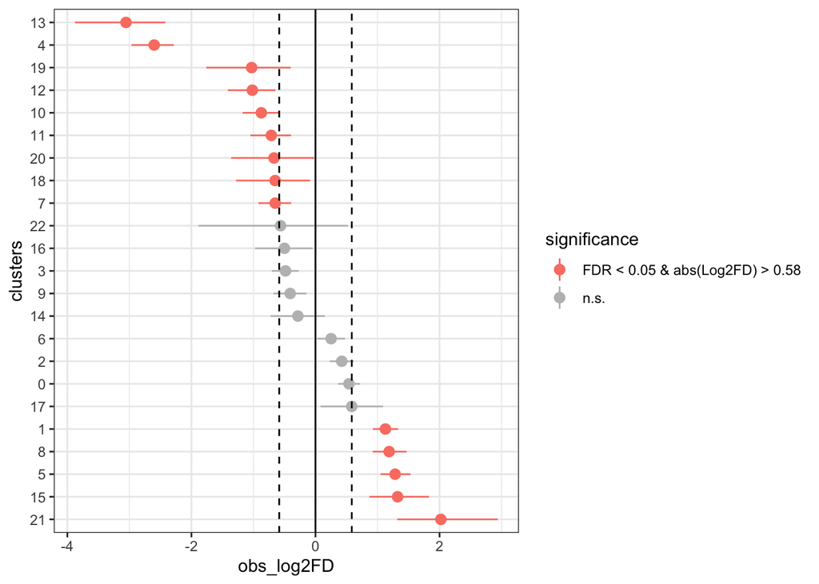

```r
FDR_threshold = 0.05
log2FD_threshold = log2(1.5)
order_clusters = TRUE

plot_data[, significance := ifelse(
  FDR < FDR_threshold & abs(obs_log2FD) > log2FD_threshold,
  paste("FDR <", FDR_threshold, "& abs(Log2FD) >", round(log2FD_threshold, 2)),
  "n.s."
)]

plot_data[, significance := factor(significance, levels = c(
  paste("FDR <", FDR_threshold, "& abs(Log2FD) >", round(log2FD_threshold, 2)),
  "n.s."
))]

#library(tidyverse)
## Order the clusters by observed log2FD if requested.
if (order_clusters) {
  plot_data[, clusters := fct_reorder(factor(clusters), dplyr::desc(obs_log2FD))]
}

## Plot the results.
p <- ggplot(plot_data, aes(x = clusters, y = obs_log2FD)) +
  geom_pointrange(aes(ymin = boot_CI_2.5, ymax = boot_CI_97.5, color = significance)) +
  theme_bw() +
  geom_hline(yintercept = log2FD_threshold, lty = 2) +
  geom_hline(yintercept = -log2FD_threshold, lty = 2) +
  geom_hline(yintercept = 0) +
  scale_color_manual(values = c("salmon", "grey")) +
  coord_flip()

p
```

```r
ggsave(paste(outputpath,"LCMV-cluster_proportion_test_labelled_scassist.pdf",sep=""), plot=p)
```

## 9. Pathway Enrichment Analysis

Here we perform pathway enrichment analysis for CD4+ clusters 15 and 13 that are different between WT vs KO in proportion test, as well as expressed the CD4+ marker Ly6c1. NOTE: cluster 13 is also identified by computational methods as “Interferon-stimulated cells”, which seems to be close to absent in the KO. SCassist does not perform enrichment analysis, but takes the clusterprofiler output for KEGG pathway and GO enrichment and tries to understand how the identified pathways could represent the system.

```r
########################### tables

# Current identity levels
levels(allsamplesgood)
```

```
##  [1] "0"  "1"  "2"  "3"  "4"  "5"  "6"  "7"  "8"  "9"  "10" "11" "12" "13" "14"
## [16] "15" "16" "17" "18" "19" "20" "21" "22"
```

```r
head(Idents(allsamplesgood))
```

```
## AAACCCAAGAGTTGTA-WT AAACCCAAGATTTGCC-WT AAACCCACAAGTATCC-WT AAACCCAGTCCAGGTC-WT
##                   9                   6                  18                  13
## AAACCCATCCTGGGAC-WT AAACGAACAGAGAGGG-WT
##                   3                   8
## Levels: 0 1 2 3 4 5 6 7 8 9 10 11 12 13 14 15 16 17 18 19 20 21 22
```

```r
# Extract markers for cluster
# Filter the dataframe for cluster 13 and 15 (CD4+)
# Filter the dataframe for cluster 13, p-value <= 0.05, and |avg_log2FC| > 1
cluster13_markers <- markersall[
  markersall$cluster == 13 &
  markersall$p_val <= 0.05 &
  abs(markersall$avg_log2FC) > 1,
]

# Run enrichment analysis using 'mouse' database, with experimental_design, pvalue and log2FC cut off values
scassist_pathway_summary_13 <- SCassist_analyze_enrichment(markers=cluster13_markers,organism = "mouse", experimental_design = experimental_design, pvalue=0.05, log2FC=1, api_key_file = api_key_file, llm_server = "google")
```

```
##
## The KEGG analysis is presented below.
## -------------------------------------------
##
## The ClusterProfiler KEGG pathways result is saved as a text file in the current working directory.
##
## The list of significantly enriched KEGG pathways is also saved as a text file in the current working directory.
##
## KEGG Enrichment Insights:
## ## Analysis of KEGG Pathway Enrichment Results
##
## ### 1. Significant Pathways:
##
## The KEGG pathway enrichment analysis reveals a complex interplay of pathways involved in immune response, cancer, and cellular processes in NK, CD4+, and CD8+ T cells from lymphocytic choriomeningitis virus (LCMV) infected WT and Ifng-CTCF binding site mutant mice.  Several pathways related to ca…
##
## ### 2. Regulators:
##
## Several transcription factors are present in the enriched pathways, suggesting their potential involvement in regulating the observed gene expression changes.  These include STAT1, JUN, NFKBIA, and SMAD3, all known to play critical roles in immune cell activation and differentiation.  STAT1 is a …
##
## ### 3. Key Genes or Potential Targets:
##
## Several genes from the enriched pathways could be crucial to the system under investigation.  For instance, *Pik3r1* (phosphoinositide-3-kinase regulatory subunit 1) is a key component of the PI3K-Akt signaling pathway, which is involved in cell survival, proliferation, and immune responses.  *If…
##
## The GO analysis is provided below.
## ----------------------------------------
##
## The ClusterProfiler GO enrichment result is saved as a text file in the current working directory.
##
## The list of significantly enriched GO terms is also saved as a text file in the current working directory.
##
## GO Enrichment Insights:
## ## 1. Significant Concepts:
##
## The GO enrichment results reveal a complex interplay of cellular processes in NK, CD4+, and CD8+ T cells from lymphocytic choriomeningitis virus (LCMV) infected mice.  A prominent theme is the **activation and differentiation of immune cells**, particularly T cells, with significant enrichment fo…
##
## ## 2. Regulators:
##
## Several transcription factors are enriched in the GO analysis, suggesting their potential involvement in regulating the immune response to LCMV infection.  For example, **Tbx21** (T-bet) is a key regulator of T helper 1 (Th1) cell differentiation, while **Foxp3** is crucial for regulatory T cell …
##
## ## 3. Key Genes or Potential Targets:
```

[output cut: 9 more lines]

```
##
## * **Cancer-related pathways:**  Enrichment of pathways like "Central carbon metabolism in cancer", "Choline metabolism in cancer", "MicroRNAs in cancer", and "Proteoglycans in cancer" suggests a potential link between LCMV infection and tumorigenesis.
## * **Immune cell signaling and function:**  Prominent pathways include "PD-L1 expression and PD-1 checkpoint pathway in cancer", "T cell receptor signaling pathway", "Chemokine signaling pathway", and "Natural killer cell mediated cytotoxicity", highlighting the crucial role of immune cells in con…
## * **Key regulators:**  Transcription factors like STAT1, JUN, NFKBIA, and SMAD3 are present in the enriched pathways, suggesting their involvement in regulating gene expression changes related to immune cell activation and differentiation.
## * **Potential targets:**  Genes like *Pik3r1*, *Ifng*, *Cd274*, *Casp3*, and *Tnf* are identified as potential targets for therapeutic interventions aimed at modulating immune responses and controlling LCMV infection.
##
## **GO Enrichment:**
##
## * **Immune cell activation and differentiation:**  Significant enrichment for terms like "T cell activation involved in immune response", "CD4-positive, alpha-beta T cell activation", and "T cell differentiation" suggests a robust immune response to LCMV infection, potentially influenced by the I…
## * **DNA damage response and repair:**  Enrichment for terms related to DNA damage response and repair indicates a significant impact of LCMV infection on cellular integrity, potentially leading to cell cycle arrest and apoptosis.
## * **Apoptosis:**  Enrichment for terms related to apoptosis in various cell types, including T cells, B cells, and macrophages, further supports the impact of LCMV infection on cellular integrity.
## * **Key regulators:**  Transcription factors like Tbx21, Foxp3, Irf1, Irf4, Eomes, and Gata3 are enriched, suggesting their potential involvement in regulating the immune response to LCMV infection.
## * **Potential targets:**  Genes like *Ifng*, *Cd274*, *Cd44*, *Ripk2*, *Il2ra*, *Tbx21*, and *Foxp3* are identified as potential targets for further investigation due to their crucial roles in immune response and cellular processes.
##
## **Overall, the combined KEGG and GO enrichment results suggest a complex interplay of pathways and cellular processes involved in the immune response to LCMV infection, potentially influenced by the Ifng-CTCF binding site mutation. The identified key regulators and potential targets provide valua…
```

```r
# Network style summary of the enrichment analysis of Cluster 13
scassist_pathway_summary_13
```

[interactive chart not shown]

```r
# Filter the dataframe for cluster 15, p-value <= 0.05, and |avg_log2FC| > 1
cluster15_markers <- markersall[
  markersall$cluster == 15 &
  markersall$p_val <= 0.05 &
  abs(markersall$avg_log2FC) > 1,
]

# Run enrichment analysis using 'mouse' database, with experimental_design, pvalue and log2FC cut off values
scassist_pathway_summary_15 <- SCassist_analyze_enrichment(markers=cluster15_markers,organism = "mouse", experimental_design = experimental_design, pvalue=0.05, log2FC=1, api_key_file = api_key_file, llm_server = "google")
```

```
##
## The KEGG analysis is presented below.
## -------------------------------------------
##
## The ClusterProfiler KEGG pathways result is saved as a text file in the current working directory.
##
## The list of significantly enriched KEGG pathways is also saved as a text file in the current working directory.
##
## KEGG Enrichment Insights:
## ## Analysis of KEGG Pathway Enrichment Results
##
## **1. Significant Pathways:**
##
## The KEGG pathway enrichment analysis reveals a complex interplay of pathways involved in immune response, cancer, and cellular processes in NK, CD4+, and CD8+ T cells from lymphocytic choriomeningitis virus (LCMV) infected WT and Ifng-CTCF binding site mutant mice.  Several pathways related to ca…
##
## **2. Regulators:**
##
## Several transcription factors are identified within the enriched pathways, potentially playing a role in regulating the observed changes in gene expression.  These include "Maf", "Hif1a", "Runx2", "Cebpa", "Tcf7", "Lef1", "E2f2", "Pparg", and "Gata3".  These transcription factors are known to be …
##
## **3. Key Genes or Potential Targets:**
##
## Several genes from the enriched pathways stand out as potential targets for further investigation due to their potential impact on the system.  "Ifng" itself, being the gene affected by the CTCF binding site mutation, is a key player in immune response and could be directly involved in the observ…
##
## The GO analysis is provided below.
## ----------------------------------------
##
## The ClusterProfiler GO enrichment result is saved as a text file in the current working directory.
##
## The list of significantly enriched GO terms is also saved as a text file in the current working directory.
##
## GO Enrichment Insights:
## ## 1. Significant Concepts:
##
## The GO enrichment results reveal a complex interplay of biological processes in NK, CD4+, and CD8+ T cells from lymphocytic choriomeningitis virus (LCMV)-infected mice.  Several concepts highlight the immune response to viral infection, including T cell activation, differentiation, and proliferat…
##
## Furthermore, the enrichment analysis reveals significant involvement of metabolic processes, particularly those related to amino acids, lipids, and carbohydrates.  This suggests that metabolic reprogramming plays a crucial role in the immune response to LCMV infection, potentially influencing cel…
##
## ## 2. Regulators:
##
## Several transcription factors are enriched in the GO analysis, suggesting their potential involvement in regulating the immune response to LCMV infection.  For example, **Foxp3**, a key regulator of regulatory T cell (Treg) differentiation, is significantly enriched in several GO terms related to…
```

[output cut: 18 more lines]

```
## * **Immune response:**  GO terms related to T cell activation, differentiation, proliferation, cytokine production, and immune response regulation highlight the complex immune response to viral infection.
## * **Cellular processes:**  Enrichment of terms related to cell migration, adhesion, and death suggests a dynamic interplay between immune cells and their environment.
## * **Metabolic processes:**  Significant involvement of metabolic processes, particularly those related to amino acids, lipids, and carbohydrates, suggests a crucial role for metabolic reprogramming in the immune response to LCMV infection.
## * **Key regulators:**  Transcription factors like Foxp3, Gata3, Eomes, and Batf are enriched in GO terms related to T cell activation, differentiation, and cytokine production, suggesting their potential involvement in shaping the immune response.
##
## **Key Genes and Potential Targets:**
##
## * **Ifng:**  The gene directly affected by the CTCF binding site mutation, likely playing a key role in the altered immune response observed in mutant mice.
## * **Il2ra:**  Involved in T cell activation and proliferation, its dysregulation could contribute to the altered immune response in mutant mice.
## * **Cd28:**  A co-stimulatory molecule crucial for T cell activation, potentially involved in the altered immune response.
## * **Ripk3:**  A key regulator of necroptosis, potentially involved in the altered immune response and cell fate decisions.
## * **Prdx4:**  A peroxiredoxin involved in oxidative stress response, potentially involved in the altered metabolic reprogramming and cell survival in mutant mice.
## * **Hif1a:**  A transcription factor involved in hypoxia response, potentially involved in the altered metabolic reprogramming and cell survival in mutant mice.
##
## **Overall, this combined analysis suggests that LCMV infection, particularly in the context of the Ifng-CTCF mutation, significantly impacts immune cell function, differentiation, and metabolic reprogramming. Further investigation of the identified key genes and regulators could provide valuable …
```

```r
# Network style summary of the enrichment analysis
scassist_pathway_summary_15
```

[interactive chart not shown]

## 10. Save